# Part I - (Prosper Loan Data)

## by (Rabiat Ohunene IBRAHIM)

- Introduction
- Preliminary Wrangling
- Univariate Exploration
- Bivariate Exploration
- Multivariate Exploration
- Conclusions

## Introduction

> This project explore the Prosper loan loan data set. The data set contains 113,937 observations 81 variables which includes, loan amount, borrower rate (or interest rate), current loan status, borrower income, and many others.

### What is prosper loan ?

For a better understanding of the data set we are working with, let’s briefly explain what the prosper loan platform is about.

> Prosper loan is an online loaning network involving peer-to-peer lending using the platform prosper.com. This platform allows borrowers to make post listings of loans requests. Interested lenders make their bids on these listings which becomes a loan when the lender invest his/her money by funding the full amount requested by borrower. Some of the informations contains are the time at which the loan originated, the amount requested, the loan status, the credit grade or rating of the borrower, the lender rate and the borrower rate. see http://konect.cc/networks/prosper-loans/ .

## Preliminary Wrangling

> In this section, we will carry out some brief wrangling and get familiar with the data set.

```python
# import all packages and set plots to be embedded inline
import numpy as np
import pandas as pd
import matplotlib.pyplot as plt
import seaborn as sb
from datetime import datetime
from pandas.api.types import CategoricalDtype

%matplotlib inline
pd.set_option("display.max_columns", None)
```

```python
#Load in the data set
df=pd.read_csv('prosperLoanData.csv')
```

> Accessing the data both physical and programmatically to check out for quality and tidiness issues.

```python
#Assessing the first few rows of the data
df.head(20)
```

|  | ListingKey | ListingNumber | ListingCreationDate | CreditGrade | Term | LoanStatus | ClosedDate | BorrowerAPR | BorrowerRate | LenderYield | EstimatedEffectiveYield | EstimatedLoss | EstimatedReturn | ProsperRating (numeric) | ProsperRating (Alpha) | ProsperScore | ListingCategory (numeric) | BorrowerState | Occupation | EmploymentStatus | EmploymentStatusDuration | IsBorrowerHomeowner | CurrentlyInGroup | GroupKey | DateCreditPulled | CreditScoreRangeLower | CreditScoreRangeUpper | FirstRecordedCreditLine | CurrentCreditLines | … |
| --- | --- | --- | --- | --- | --- | --- | --- | --- | --- | --- | --- | --- | --- | --- | --- | --- | --- | --- | --- | --- | --- | --- | --- | --- | --- | --- | --- | --- | --- | --- |
| 0 | 1021339766868145413AB3B | 193129 | 2007-08-26 19:09:29.263000000 | C | 36 | Completed | 2009-08-14 00:00:00 | 0.16516 | 0.1580 | 0.1380 | NaN | NaN | NaN | NaN | NaN | NaN | 0 | CO | Other | Self-employed | 2.0 | True | True | NaN | 2007-08-26 18:41:46.780000000 | 640.0 | 659.0 | 2001-10-11 00:00:00 | 5.0 | … |
| 1 | 10273602499503308B223C1 | 1209647 | 2014-02-27 08:28:07.900000000 | NaN | 36 | Current | NaN | 0.12016 | 0.0920 | 0.0820 | 0.07960 | 0.0249 | 0.05470 | 6.0 | A | 7.0 | 2 | CO | Professional | Employed | 44.0 | False | False | NaN | 2014-02-27 08:28:14 | 680.0 | 699.0 | 1996-03-18 00:00:00 | 14.0 | … |
| 2 | 0EE9337825851032864889A | 81716 | 2007-01-05 15:00:47.090000000 | HR | 36 | Completed | 2009-12-17 00:00:00 | 0.28269 | 0.2750 | 0.2400 | NaN | NaN | NaN | NaN | NaN | NaN | 0 | GA | Other | Not available | NaN | False | True | 783C3371218786870A73D20 | 2007-01-02 14:09:10.060000000 | 480.0 | 499.0 | 2002-07-27 00:00:00 | NaN | … |
| 3 | 0EF5356002482715299901A | 658116 | 2012-10-22 11:02:35.010000000 | NaN | 36 | Current | NaN | 0.12528 | 0.0974 | 0.0874 | 0.08490 | 0.0249 | 0.06000 | 6.0 | A | 9.0 | 16 | GA | Skilled Labor | Employed | 113.0 | True | False | NaN | 2012-10-22 11:02:32 | 800.0 | 819.0 | 1983-02-28 00:00:00 | 5.0 | … |
| 4 | 0F023589499656230C5E3E2 | 909464 | 2013-09-14 18:38:39.097000000 | NaN | 36 | Current | NaN | 0.24614 | 0.2085 | 0.1985 | 0.18316 | 0.0925 | 0.09066 | 3.0 | D | 4.0 | 2 | MN | Executive | Employed | 44.0 | True | False | NaN | 2013-09-14 18:38:44 | 680.0 | 699.0 | 2004-02-20 00:00:00 | 19.0 | … |
| 5 | 0F05359734824199381F61D | 1074836 | 2013-12-14 08:26:37.093000000 | NaN | 60 | Current | NaN | 0.15425 | 0.1314 | 0.1214 | 0.11567 | 0.0449 | 0.07077 | 5.0 | B | 10.0 | 1 | NM | Professional | Employed | 82.0 | True | False | NaN | 2013-12-14 08:26:40 | 740.0 | 759.0 | 1973-03-01 00:00:00 | 21.0 | … |
| 6 | 0F0A3576754255009D63151 | 750899 | 2013-04-12 09:52:56.147000000 | NaN | 36 | Current | NaN | 0.31032 | 0.2712 | 0.2612 | 0.23820 | 0.1275 | 0.11070 | 2.0 | E | 2.0 | 1 | KS | Sales - Retail | Employed | 172.0 | False | False | NaN | 2013-04-12 09:52:53 | 680.0 | 699.0 | 2000-09-29 00:00:00 | 10.0 | … |
| 7 | 0F1035772717087366F9EA7 | 768193 | 2013-05-05 06:49:27.493000000 | NaN | 36 | Current | NaN | 0.23939 | 0.2019 | 0.1919 | 0.17830 | 0.0799 | 0.09840 | 4.0 | C | 4.0 | 2 | CA | Laborer | Employed | 103.0 | False | False | NaN | 2013-05-05 06:49:25 | 700.0 | 719.0 | 1999-02-25 00:00:00 | 6.0 | … |
| 8 | 0F043596202561788EA13D5 | 1023355 | 2013-12-02 10:43:39.117000000 | NaN | 36 | Current | NaN | 0.07620 | 0.0629 | 0.0529 | 0.05221 | 0.0099 | 0.04231 | 7.0 | AA | 9.0 | 7 | IL | Food Service | Employed | 269.0 | True | False | NaN | 2013-12-02 10:43:39 | 820.0 | 839.0 | 1993-04-01 00:00:00 | 17.0 | … |
| 9 | 0F043596202561788EA13D5 | 1023355 | 2013-12-02 10:43:39.117000000 | NaN | 36 | Current | NaN | 0.07620 | 0.0629 | 0.0529 | 0.05221 | 0.0099 | 0.04231 | 7.0 | AA | 11.0 | 7 | IL | Food Service | Employed | 269.0 | True | False | NaN | 2013-12-02 10:43:39 | 820.0 | 839.0 | 1993-04-01 00:00:00 | 17.0 | … |
| 10 | 0F123545674891886D9F106 | 587746 | 2012-05-10 07:04:01.577000000 | NaN | 60 | Current | NaN | 0.27462 | 0.2489 | 0.2389 | 0.23320 | 0.0890 | 0.14420 | 4.0 | C | 7.0 | 1 | MD | Fireman | Employed | 300.0 | False | False | NaN | 2012-04-22 08:38:09 | 640.0 | 659.0 | 1989-11-29 00:00:00 | 2.0 | … |
| 11 | 0F1734025150298088A5F2B | 213551 | 2007-10-09 20:28:33.640000000 | C | 36 | Completed | 2008-01-07 00:00:00 | 0.15033 | 0.1325 | 0.1225 | NaN | NaN | NaN | NaN | NaN | NaN | 0 | NaN | Waiter/Waitress | Full-time | 19.0 | False | False | NaN | 2007-10-08 13:13:44.363000000 | 640.0 | 659.0 | 2000-11-13 00:00:00 | 2.0 | … |
| 12 | 0F1A3597143888805163EF7 | 1081604 | 2013-12-15 20:01:10.757000000 | NaN | 36 | Past Due (1-15 days) | NaN | 0.17969 | 0.1435 | 0.1335 | 0.12640 | 0.0524 | 0.07400 | 5.0 | B | 4.0 | 1 | AL | Sales - Retail | Employed | 1.0 | False | False | NaN | 2013-12-15 20:01:13 | 680.0 | 699.0 | 1996-11-09 00:00:00 | 9.0 | … |
| 13 | 0F1C3583260311305D68F87 | 840820 | 2013-07-15 16:28:28.087000000 | NaN | 36 | Current | NaN | 0.13138 | 0.1034 | 0.0934 | 0.09050 | 0.0274 | 0.06310 | 6.0 | A | 8.0 | 1 | AZ | Construction | Employed | 98.0 | True | False | NaN | 2013-07-11 16:51:03 | 740.0 | 759.0 | 2007-03-20 00:00:00 | 9.0 | … |
| 14 | 0F353575943675863D1AFC0 | 757359 | 2013-04-19 11:17:41.700000000 | NaN | 60 | Current | NaN | 0.11695 | 0.0949 | 0.0849 | 0.08270 | 0.0224 | 0.06030 | 6.0 | A | 8.0 | 1 | VA | Computer Programmer | Employed | 35.0 | False | False | NaN | 2013-04-19 11:17:38 | 740.0 | 759.0 | 1992-07-06 00:00:00 | 25.0 | … |
| 15 | 0F483544120452347F48121 | 577164 | 2012-04-10 09:14:46.297000000 | NaN | 36 | Defaulted | 2012-12-19 00:00:00 | 0.35797 | 0.3177 | 0.3077 | 0.28960 | 0.1650 | 0.12460 | 1.0 | HR | 5.0 | 13 | FL | Other | Other | 121.0 | True | False | NaN | 2012-04-10 09:14:41 | 700.0 | 719.0 | 1999-03-08 00:00:00 | 10.0 | … |
| 16 | 0F4835843081468212F0892 | 841846 | 2013-07-16 12:42:48.680000000 | NaN | 60 | Current | NaN | 0.30748 | 0.2809 | 0.2709 | 0.24730 | 0.1225 | 0.12480 | 2.0 | E | 4.0 | 6 | CA | Professional | Full-time | 133.0 | True | False | NaN | 2013-07-16 12:42:39 | 640.0 | 659.0 | 2001-08-11 00:00:00 | 6.0 | … |
| 17 | 0FDF336575182398852A8DC | 31540 | 2006-08-15 12:21:09.433000000 | AA | 36 | Chargedoff | 2008-05-22 00:00:00 | 0.13202 | 0.1250 | 0.1175 | NaN | NaN | NaN | NaN | NaN | NaN | 0 | NaN | Professional | Not available | NaN | True | True | EF543365873906104DC9A04 | 2006-08-15 10:56:13.020000000 | 760.0 | 779.0 | 1990-05-19 00:00:00 | NaN | … |
| 18 | 0FF2357105361877390B58D | 716058 | 2013-02-20 03:48:37.470000000 | NaN | 36 | Current | NaN | 0.12528 | 0.0974 | 0.0874 | 0.08490 | 0.0249 | 0.06000 | 6.0 | A | 7.0 | 1 | PA | Sales - Commission | Employed | 179.0 | False | False | NaN | 2013-02-20 03:48:33 | 740.0 | 759.0 | 1994-12-20 00:00:00 | 10.0 | … |
| 19 | 0FFC35866018516621B0D3F | 875565 | 2013-08-21 06:49:02.093000000 | NaN | 60 | Current | NaN | 0.24754 | 0.2225 | 0.2125 | 0.19520 | 0.1025 | 0.09270 | 3.0 | D | 8.0 | 1 | OR | Laborer | Employed | 18.0 | False | False | NaN | 2013-10-04 17:49:53 | 680.0 | 699.0 | 2007-08-13 00:00:00 | 15.0 | … |

```python
#Assesing the features and data types of the dataset programmatially
df.info()
```

```
<class 'pandas.core.frame.DataFrame'>
RangeIndex: 113937 entries, 0 to 113936
Data columns (total 81 columns):
 #   Column                               Non-Null Count   Dtype
---  ------                               --------------   -----
 0   ListingKey                           113937 non-null  object
 1   ListingNumber                        113937 non-null  int64
 2   ListingCreationDate                  113937 non-null  object
 3   CreditGrade                          28953 non-null   object
 4   Term                                 113937 non-null  int64
 5   LoanStatus                           113937 non-null  object
 6   ClosedDate                           55089 non-null   object
 7   BorrowerAPR                          113912 non-null  float64
 8   BorrowerRate                         113937 non-null  float64
 9   LenderYield                          113937 non-null  float64
```

[output cut: 73 more lines]

```python
#Accessing the shape of the data set
print(df.shape)
```

```
(113937, 81)
```

```python
df.describe()
```

|  | ListingNumber | Term | BorrowerAPR | BorrowerRate | LenderYield | EstimatedEffectiveYield | EstimatedLoss | EstimatedReturn | ProsperRating (numeric) | ProsperScore | ListingCategory (numeric) | EmploymentStatusDuration | CreditScoreRangeLower | CreditScoreRangeUpper | CurrentCreditLines | OpenCreditLines | TotalCreditLinespast7years | OpenRevolvingAccounts | OpenRevolvingMonthlyPayment | InquiriesLast6Months | TotalInquiries | CurrentDelinquencies | AmountDelinquent | DelinquenciesLast7Years | PublicRecordsLast10Years | PublicRecordsLast12Months | RevolvingCreditBalance | BankcardUtilization | AvailableBankcardCredit | … |
| --- | --- | --- | --- | --- | --- | --- | --- | --- | --- | --- | --- | --- | --- | --- | --- | --- | --- | --- | --- | --- | --- | --- | --- | --- | --- | --- | --- | --- | --- | --- |
| count | 1.139370e+05 | 113937.000000 | 113912.000000 | 113937.000000 | 113937.000000 | 84853.000000 | 84853.000000 | 84853.000000 | 84853.000000 | 84853.000000 | 113937.000000 | 106312.000000 | 113346.000000 | 113346.000000 | 106333.000000 | 106333.000000 | 113240.000000 | 113937.00000 | 113937.000000 | 113240.000000 | 112778.000000 | 113240.000000 | 106315.000000 | 112947.000000 | 113240.000000 | 106333.000000 | 1.063330e+05 | 106333.000000 | 106393.000000 | … |
| mean | 6.278857e+05 | 40.830248 | 0.218828 | 0.192764 | 0.182701 | 0.168661 | 0.080306 | 0.096068 | 4.072243 | 5.950067 | 2.774209 | 96.071582 | 685.567731 | 704.567731 | 10.317192 | 9.260164 | 26.754539 | 6.96979 | 398.292161 | 1.435085 | 5.584405 | 0.592052 | 984.507059 | 4.154984 | 0.312646 | 0.015094 | 1.759871e+04 | 0.561309 | 11210.225447 | … |
| std | 3.280762e+05 | 10.436212 | 0.080364 | 0.074818 | 0.074516 | 0.068467 | 0.046764 | 0.030403 | 1.673227 | 2.376501 | 3.996797 | 94.480605 | 66.458275 | 66.458275 | 5.457866 | 5.022644 | 13.637871 | 4.63097 | 447.159711 | 2.437507 | 6.429946 | 1.978707 | 7158.270157 | 10.160216 | 0.727868 | 0.154092 | 3.293640e+04 | 0.317918 | 19818.361309 | … |
| min | 4.000000e+00 | 12.000000 | 0.006530 | 0.000000 | -0.010000 | -0.182700 | 0.004900 | -0.182700 | 1.000000 | 1.000000 | 0.000000 | 0.000000 | 0.000000 | 19.000000 | 0.000000 | 0.000000 | 2.000000 | 0.00000 | 0.000000 | 0.000000 | 0.000000 | 0.000000 | 0.000000 | 0.000000 | 0.000000 | 0.000000 | 0.000000e+00 | 0.000000 | 0.000000 | … |
| 25% | 4.009190e+05 | 36.000000 | 0.156290 | 0.134000 | 0.124200 | 0.115670 | 0.042400 | 0.074080 | 3.000000 | 4.000000 | 1.000000 | 26.000000 | 660.000000 | 679.000000 | 7.000000 | 6.000000 | 17.000000 | 4.00000 | 114.000000 | 0.000000 | 2.000000 | 0.000000 | 0.000000 | 0.000000 | 0.000000 | 0.000000 | 3.121000e+03 | 0.310000 | 880.000000 | … |
| 50% | 6.005540e+05 | 36.000000 | 0.209760 | 0.184000 | 0.173000 | 0.161500 | 0.072400 | 0.091700 | 4.000000 | 6.000000 | 1.000000 | 67.000000 | 680.000000 | 699.000000 | 10.000000 | 9.000000 | 25.000000 | 6.00000 | 271.000000 | 1.000000 | 4.000000 | 0.000000 | 0.000000 | 0.000000 | 0.000000 | 0.000000 | 8.549000e+03 | 0.600000 | 4100.000000 | … |
| 75% | 8.926340e+05 | 36.000000 | 0.283810 | 0.250000 | 0.240000 | 0.224300 | 0.112000 | 0.116600 | 5.000000 | 8.000000 | 3.000000 | 137.000000 | 720.000000 | 739.000000 | 13.000000 | 12.000000 | 35.000000 | 9.00000 | 525.000000 | 2.000000 | 7.000000 | 0.000000 | 0.000000 | 3.000000 | 0.000000 | 0.000000 | 1.952100e+04 | 0.840000 | 13180.000000 | … |
| max | 1.255725e+06 | 60.000000 | 0.512290 | 0.497500 | 0.492500 | 0.319900 | 0.366000 | 0.283700 | 7.000000 | 11.000000 | 20.000000 | 755.000000 | 880.000000 | 899.000000 | 59.000000 | 54.000000 | 136.000000 | 51.00000 | 14985.000000 | 105.000000 | 379.000000 | 83.000000 | 463881.000000 | 99.000000 | 38.000000 | 20.000000 | 1.435667e+06 | 5.950000 | 646285.000000 | … |

```python
loan_df= df.copy()
```

```python
reduced_loan_df=loan_df[['TotalInquiries', 'AvailableBankcardCredit', 'LoanStatus','BorrowerAPR', 'ProsperScore',
                         'LoanOriginationDate','LoanOriginalAmount', 'Occupation', 'EmploymentStatus',
                        'IncomeRange', 'IncomeVerifiable', 'StatedMonthlyIncome', 'TotalCreditLinespast7years',
                         'DelinquenciesLast7Years', 'DebtToIncomeRatio', 'MonthlyLoanPayment', 'IsBorrowerHomeowner',
                         'Term', 'BorrowerRate', 'ListingCategory (numeric)', 'CurrentCreditLines',
                         'TotalInquiries', 'TotalProsperLoans', 'OnTimeProsperPayments',
                         'ProsperPaymentsLessThanOneMonthLate', 'ProsperPaymentsOneMonthPlusLate',
                         'ScorexChangeAtTimeOfListing', 'LoanOriginalAmount', 'LoanMonthsSinceOrigination',
                         'EmploymentStatusDuration', 'CreditScoreRangeLower', 'CreditScoreRangeUpper'  ]]
```

```python
reduced_loan_df.head()
```

|  | TotalInquiries | AvailableBankcardCredit | LoanStatus | BorrowerAPR | ProsperScore | LoanOriginationDate | LoanOriginalAmount | Occupation | EmploymentStatus | IncomeRange | IncomeVerifiable | StatedMonthlyIncome | TotalCreditLinespast7years | DelinquenciesLast7Years | DebtToIncomeRatio | MonthlyLoanPayment | IsBorrowerHomeowner | Term | BorrowerRate | ListingCategory (numeric) | CurrentCreditLines | TotalInquiries | TotalProsperLoans | OnTimeProsperPayments | ProsperPaymentsLessThanOneMonthLate | ProsperPaymentsOneMonthPlusLate | ScorexChangeAtTimeOfListing | LoanOriginalAmount | LoanMonthsSinceOrigination | … |
| --- | --- | --- | --- | --- | --- | --- | --- | --- | --- | --- | --- | --- | --- | --- | --- | --- | --- | --- | --- | --- | --- | --- | --- | --- | --- | --- | --- | --- | --- | --- |
| 0 | 3.0 | 1500.0 | Completed | 0.16516 | NaN | 2007-09-12 00:00:00 | 9425 | Other | Self-employed | $25,000-49,999 | True | 3083.333333 | 12.0 | 4.0 | 0.17 | 330.43 | True | 36 | 0.1580 | 0 | 5.0 | 3.0 | NaN | NaN | NaN | NaN | NaN | 9425 | 78 | … |
| 1 | 5.0 | 10266.0 | Current | 0.12016 | 7.0 | 2014-03-03 00:00:00 | 10000 | Professional | Employed | $50,000-74,999 | True | 6125.000000 | 29.0 | 0.0 | 0.18 | 318.93 | False | 36 | 0.0920 | 2 | 14.0 | 5.0 | NaN | NaN | NaN | NaN | NaN | 10000 | 0 | … |
| 2 | 1.0 | NaN | Completed | 0.28269 | NaN | 2007-01-17 00:00:00 | 3001 | Other | Not available | Not displayed | True | 2083.333333 | 3.0 | 0.0 | 0.06 | 123.32 | False | 36 | 0.2750 | 0 | NaN | 1.0 | NaN | NaN | NaN | NaN | NaN | 3001 | 86 | … |
| 3 | 1.0 | 30754.0 | Current | 0.12528 | 9.0 | 2012-11-01 00:00:00 | 10000 | Skilled Labor | Employed | $25,000-49,999 | True | 2875.000000 | 29.0 | 14.0 | 0.15 | 321.45 | True | 36 | 0.0974 | 16 | 5.0 | 1.0 | NaN | NaN | NaN | NaN | NaN | 10000 | 16 | … |
| 4 | 9.0 | 695.0 | Current | 0.24614 | 4.0 | 2013-09-20 00:00:00 | 15000 | Executive | Employed | $100,000+ | True | 9583.333333 | 49.0 | 0.0 | 0.26 | 563.97 | True | 36 | 0.2085 | 2 | 19.0 | 9.0 | 1.0 | 11.0 | 0.0 | 0.0 | NaN | 15000 | 6 | … |

```python
reduced_loan_df.sample(20)
```

|  | TotalInquiries | AvailableBankcardCredit | LoanStatus | BorrowerAPR | ProsperScore | LoanOriginationDate | LoanOriginalAmount | Occupation | EmploymentStatus | IncomeRange | IncomeVerifiable | StatedMonthlyIncome | TotalCreditLinespast7years | DelinquenciesLast7Years | DebtToIncomeRatio | MonthlyLoanPayment | IsBorrowerHomeowner | Term | BorrowerRate | ListingCategory (numeric) | CurrentCreditLines | TotalInquiries | TotalProsperLoans | OnTimeProsperPayments | ProsperPaymentsLessThanOneMonthLate | ProsperPaymentsOneMonthPlusLate | ScorexChangeAtTimeOfListing | LoanOriginalAmount | LoanMonthsSinceOrigination | … |
| --- | --- | --- | --- | --- | --- | --- | --- | --- | --- | --- | --- | --- | --- | --- | --- | --- | --- | --- | --- | --- | --- | --- | --- | --- | --- | --- | --- | --- | --- | --- |
| 108037 | 2.0 | 592.0 | Current | 0.35797 | 6.0 | 2012-09-11 00:00:00 | 4000 | Military Enlisted | Employed | $50,000-74,999 | True | 4333.333333 | 12.0 | 0.0 | 0.35 | 173.71 | False | 36 | 0.3177 | 1 | 8.0 | 2.0 | NaN | NaN | NaN | NaN | NaN | 4000 | 18 | … |
| 104559 | 10.0 | 0.0 | Defaulted | 0.30564 | NaN | 2007-04-11 00:00:00 | 3001 | Sales - Commission | Full-time | $75,000-99,999 | True | 7500.000000 | 10.0 | 3.0 | 0.16 | 125.76 | True | 36 | 0.2900 | 0 | 4.0 | 10.0 | NaN | NaN | NaN | NaN | NaN | 3001 | 83 | … |
| 2149 | 3.0 | 5143.0 | Current | 0.14965 | 10.0 | 2013-05-08 00:00:00 | 34999 | Computer Programmer | Employed | $100,000+ | True | 8833.333333 | 16.0 | 3.0 | 0.20 | 790.79 | True | 60 | 0.1269 | 1 | 9.0 | 3.0 | 1.0 | 26.0 | 0.0 | 0.0 | -77.0 | 34999 | 10 | … |
| 81036 | 2.0 | 5894.0 | Current | 0.13250 | 11.0 | 2014-02-20 00:00:00 | 15500 | Professional | Employed | $75,000-99,999 | True | 6356.416667 | 29.0 | 0.0 | 0.25 | 336.93 | False | 60 | 0.1099 | 1 | 10.0 | 2.0 | 1.0 | 6.0 | 0.0 | 0.0 | NaN | 15500 | 1 | … |
| 51630 | 10.0 | 7737.0 | Past Due (61-90 days) | 0.26877 | 3.0 | 2013-06-06 00:00:00 | 10000 | Other | Employed | $25,000-49,999 | True | 3500.000000 | 12.0 | 0.0 | 0.22 | 289.54 | True | 60 | 0.2432 | 2 | 10.0 | 10.0 | NaN | NaN | NaN | NaN | NaN | 10000 | 9 | … |
| 77674 | 10.0 | 17883.0 | Current | 0.25677 | 4.0 | 2014-03-11 00:00:00 | 9000 | Administrative Assistant | Employed | $50,000-74,999 | True | 4500.000000 | 24.0 | 24.0 | 0.27 | 343.02 | True | 36 | 0.2185 | 7 | 5.0 | 10.0 | 1.0 | 2.0 | 0.0 | 0.0 | -14.0 | 9000 | 0 | … |
| 24267 | 8.0 | 1932.0 | Defaulted | 0.13619 | NaN | 2008-04-01 00:00:00 | 15000 | Computer Programmer | Full-time | $50,000-74,999 | True | 5833.333333 | 34.0 | 0.0 | 0.23 | 381.49 | True | 36 | 0.1315 | 1 | 9.0 | 8.0 | NaN | NaN | NaN | NaN | NaN | 15000 | 71 | … |
| 34480 | 5.0 | 18463.0 | Past Due (61-90 days) | 0.20462 | 9.0 | 2012-09-07 00:00:00 | 11000 | Professional | Employed | $75,000-99,999 | True | 7500.000000 | 9.0 | 0.0 | 0.06 | 391.03 | False | 36 | 0.1679 | 1 | 4.0 | 5.0 | NaN | NaN | NaN | NaN | NaN | 11000 | 18 | … |
| 72742 | 4.0 | 813.0 | Past Due (1-15 days) | 0.26681 | 6.0 | 2012-06-26 00:00:00 | 15000 | Executive | Employed | $100,000+ | True | 10541.666667 | 30.0 | 5.0 | 0.22 | 579.63 | False | 36 | 0.2287 | 1 | 9.0 | 4.0 | 1.0 | 32.0 | 4.0 | 0.0 | -18.0 | 15000 | 21 | … |
| 93096 | 5.0 | 12939.0 | Current | 0.26047 | 4.0 | 2013-11-15 00:00:00 | 10000 | Nurse (RN) | Employed | $50,000-74,999 | True | 6000.000000 | 32.0 | 0.0 | 0.47 | 383.20 | True | 36 | 0.2225 | 1 | 18.0 | 5.0 | NaN | NaN | NaN | NaN | NaN | 10000 | 4 | … |
| 21551 | 4.0 | 26688.0 | Current | 0.14147 | 10.0 | 2013-12-09 00:00:00 | 20000 | Analyst | Employed | $75,000-99,999 | True | 6666.666667 | 39.0 | 0.0 | 0.27 | 443.78 | True | 60 | 0.1189 | 1 | 17.0 | 4.0 | NaN | NaN | NaN | NaN | NaN | 20000 | 3 | … |
| 55204 | 2.0 | 12272.0 | Current | 0.25102 | 7.0 | 2013-03-28 00:00:00 | 25000 | Other | Employed | $100,000+ | True | 8666.666667 | 27.0 | 4.0 | 0.18 | 698.89 | False | 60 | 0.2259 | 1 | 15.0 | 2.0 | NaN | NaN | NaN | NaN | NaN | 25000 | 12 | … |
| 79590 | 2.0 | 4812.0 | Current | 0.13109 | 8.0 | 2011-03-28 00:00:00 | 15000 | Doctor | Full-time | $100,000+ | True | 15416.666667 | 30.0 | 3.0 | 0.09 | 491.01 | False | 36 | 0.1099 | 1 | 8.0 | 2.0 | 1.0 | 33.0 | 0.0 | 0.0 | -30.0 | 15000 | 36 | … |
| 101475 | 9.0 | NaN | Completed | 0.20795 | NaN | 2007-01-17 00:00:00 | 1000 | Professional | Not available | Not displayed | True | 3500.000000 | 16.0 | 40.0 | 0.02 | 15.90 | True | 36 | 0.1895 | 0 | NaN | 9.0 | NaN | NaN | NaN | NaN | NaN | 1000 | 86 | … |
| 87012 | 1.0 | 41608.0 | Current | 0.13227 | 8.0 | 2013-09-04 00:00:00 | 20000 | Attorney | Employed | $100,000+ | True | 9750.000000 | 23.0 | 4.0 | 0.15 | 434.75 | True | 60 | 0.1099 | 1 | 9.0 | 1.0 | NaN | NaN | NaN | NaN | NaN | 20000 | 6 | … |
| 83619 | 4.0 | 70950.0 | Completed | 0.11094 | 9.0 | 2009-09-15 00:00:00 | 5300 | Engineer - Mechanical | Full-time | $50,000-74,999 | True | 5416.666667 | 44.0 | 0.0 | 0.05 | 168.54 | True | 36 | 0.0900 | 6 | 15.0 | 4.0 | NaN | NaN | NaN | NaN | NaN | 5300 | 54 | … |
| 66612 | 16.0 | 8625.0 | Current | 0.20081 | 6.0 | 2013-06-14 00:00:00 | 25000 | Retail Management | Employed | $100,000+ | True | 10000.000000 | 57.0 | 2.0 | 0.23 | 630.63 | True | 60 | 0.1769 | 1 | 22.0 | 16.0 | NaN | NaN | NaN | NaN | NaN | 25000 | 9 | … |
| 86501 | 48.0 | NaN | Defaulted | 0.19730 | NaN | 2007-01-17 00:00:00 | 12000 | Accountant/CPA | Not available | Not displayed | True | 4325.000000 | 59.0 | 7.0 | 0.28 | 439.87 | True | 36 | 0.1900 | 0 | NaN | 48.0 | NaN | NaN | NaN | NaN | NaN | 12000 | 86 | … |
| 38868 | 10.0 | 6799.0 | Completed | 0.27285 | 2.0 | 2013-08-12 00:00:00 | 4000 | Other | Other | $25,000-49,999 | False | 3333.333333 | 22.0 | 0.0 | NaN | 155.80 | False | 36 | 0.2346 | 1 | 8.0 | 10.0 | NaN | NaN | NaN | NaN | NaN | 4000 | 7 | … |
| 19866 | 5.0 | 4060.0 | Current | 0.32321 | 2.0 | 2012-12-27 00:00:00 | 4000 | Skilled Labor | Employed | $25,000-49,999 | True | 3750.000000 | 18.0 | 7.0 | 0.31 | 128.48 | False | 60 | 0.2962 | 7 | 7.0 | 5.0 | 1.0 | 9.0 | 0.0 | 0.0 | -52.0 | 4000 | 15 | … |

```python
reduced_loan_df.info()
```

```
<class 'pandas.core.frame.DataFrame'>
RangeIndex: 113937 entries, 0 to 113936
Data columns (total 32 columns):
 #   Column                               Non-Null Count   Dtype
---  ------                               --------------   -----
 0   TotalInquiries                       112778 non-null  float64
 1   AvailableBankcardCredit              106393 non-null  float64
 2   LoanStatus                           113937 non-null  object
 3   BorrowerAPR                          113912 non-null  float64
 4   ProsperScore                         84853 non-null   float64
 5   LoanOriginationDate                  113937 non-null  object
 6   LoanOriginalAmount                   113937 non-null  int64
 7   Occupation                           110349 non-null  object
 8   EmploymentStatus                     111682 non-null  object
 9   IncomeRange                          113937 non-null  object
```

[output cut: 24 more lines]

```python
reduced_loan_df.IncomeRange.value_counts()
```

```
$25,000-49,999    32192
$50,000-74,999    31050
$100,000+         17337
$75,000-99,999    16916
Not displayed      7741
$1-24,999          7274
Not employed        806
$0                  621
Name: IncomeRange, dtype: int64
```

The income range column has variable `Not employed` which is not appropriate.

The Income range should be a cathegorical data

### Quality issues (reduced_loan_df)

#### Incorrect datatypes

> 1. The cathegorical feature, `ListingCategory (numeric)` should be of string data type.
> 2. The `ProsperScore` should be of cathegorical data type
> 3. The Income range should be a cathegorical data.

#### Other quality issues

> 1. The income range column has variable `Not employed` which is not appropriate.

### Cleaning (reduced_loan_df)

#### Quality issue 1: The cathegorical feature, `ListingCategory (numeric)` should be of string data type.

```python
# Make a copy of the original data set
reduced_loan_clean=reduced_loan_df.copy()
```

##### Define

Convert `ListingCategory (numeric)` to string datatype

##### Code

```python
reduced_loan_clean['ListingCategory (numeric)']= reduced_loan_clean['ListingCategory (numeric)'].astype(str)
```

##### Test

```python
reduced_loan_clean['ListingCategory (numeric)'].dtype
```

```
dtype('O')
```

#### Quality issue 2 : The`ProsperScore` should be of cathegorical data type.

##### Define

Covert `ProsperScore` to cathegorical data type.

##### Code

```python
#Convert ProsperScore to cathegorical data type
reduced_loan_clean['ProsperScore'] = reduced_loan_clean.ProsperScore.astype('category')
```

##### Test

```python
reduced_loan_clean['ProsperScore'].dtype
```

```
CategoricalDtype(categories=[1.0, 2.0, 3.0, 4.0, 5.0, 6.0, 7.0, 8.0, 9.0, 10.0, 11.0], ordered=False)
```

```python
reduced_loan_clean.ProsperScore.value_counts()
```

```
4.0     12595
6.0     12278
8.0     12053
7.0     10597
5.0      9813
3.0      7642
9.0      6911
2.0      5766
10.0     4750
11.0     1456
1.0       992
Name: ProsperScore, dtype: int64
```

#### Quality Issues 3 and 4

###### The Income range should be a cathegorical data

###### The income range column has variable `Not employed` which is not appropriate.

##### Define

> Convert observation: `Not employed` to income range of 0.

> Convert the income range to cathegorical data.

##### Code

```python
#Get the value counts of the column
reduced_loan_clean.IncomeRange.value_counts()
```

```
$25,000-49,999    32192
$50,000-74,999    31050
$100,000+         17337
$75,000-99,999    16916
Not displayed      7741
$1-24,999          7274
Not employed        806
$0                  621
Name: IncomeRange, dtype: int64
```

```python
#Replace 'Not employed' with $0
reduced_loan_clean['IncomeRange']=reduced_loan_clean['IncomeRange'].replace(to_replace='Not employed', value= '$0')

#Convert the income range into categorical datatype
ordered_var = CategoricalDtype(categories=['$0','$1-24,999','$25,000-49,999','$50,000-74,999','$75,000-99,999',
                                           '$100,000+'], ordered=True)
reduced_loan_clean['IncomeRange'] = reduced_loan_clean['IncomeRange'].astype(ordered_var)
```

##### Test

```python
reduced_loan_clean.IncomeRange.dtype
```

```
CategoricalDtype(categories=['$0', '$1-24,999', '$25,000-49,999', '$50,000-74,999',
                  '$75,000-99,999', '$100,000+'],
, ordered=True)
```

### What is/are the main feature(s) of interest in your dataset?

> First of all, major feature of interest to me in the data set is the `BorrowerAPI`. That is what feature(s) affect the borrower's annual percentage rate?

> It will also be interesting to understand the `Loanstatus`. That is what affects the outcome of the loan?

### What features in the dataset do you think will help support your investigation into your feature(s) of interest?

> The features in the dataset I think will support my chosen features of interest are `IncomeRange`, `BorrowerAPR`, `DebtToIncomeRatio`, `ProsperScore`, `CreditScoreRangeLower` and `CreditScoreRangeUpper`.

## Univariate Exploration

> In this section, we investigate distributions of individual variables.

#### Plotting functions

Since we are going to make several visualization in this section, its best to define a plotting function for various. plots.

```python
#Function that plots bar chart

def barchartplot(data, catvar):
    '''Takes in a dataset and a cathigorical variable in the dataset
    as an input and plots a barchart as an output'''
    colors=sb.color_palette()[0]
    plt.figure(figsize=(10,8))
    sb.countplot(data=data, x=catvar, color=colors);





#Function to plot histogram
def histchartplot(data, numvar, bins):
    '''Takes in a dataset and a numerical variable in the dataset
    as an input and plots a histogram as an output'''
    colors=sb.color_palette()[0]
    plt.figure(figsize=(5,5))
    plt.hist(data=data, x=numvar, color=colors, bins=bins);
```

First I will like to explore one of my variable of interest which is the `Loanstatus`. Let's see the distribution of the loan status. Since loan status is a categorical data, we will explore it using a bar chat.

### Questions

> How is the distribution of the loan status; How much of the loan is completed, current and defaults ?

### Visualization

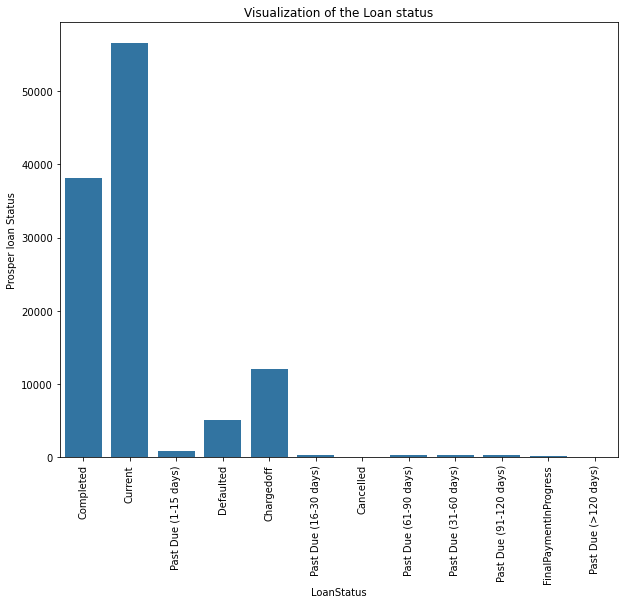

```python
barchartplot(reduced_loan_clean, 'LoanStatus')
plt.title('Visualization of the Loan status');
plt.ylabel('Prosper loan Status')
plt.xticks(rotation=90);
```

```python
#The different counts of the loanstatus
reduced_loan_clean.LoanStatus.value_counts()
```

```
Current                   56576
Completed                 38074
Chargedoff                11992
Defaulted                  5018
Past Due (1-15 days)        806
Past Due (31-60 days)       363
Past Due (61-90 days)       313
Past Due (91-120 days)      304
Past Due (16-30 days)       265
FinalPaymentInProgress      205
Past Due (>120 days)         16
Cancelled                     5
Name: LoanStatus, dtype: int64
```

> We regrouped all the past due loans, defaulted, and charged off loans as an observation called `delinquent, default and charged off`. This is saved to a new column name `LoanStatusSummary`.

```python
#Regrouping the past dues
reduced_loan_clean['LoanStatusSummary']=reduced_loan_clean['LoanStatus'].replace(['Past Due (1-15 days)',
                                                                                  'Past Due (31-60 days)',
                                                                                  'Past Due (61-90 days)',
                                                                                  'Past Due (91-120 days)',
                                                                                  'Past Due (16-30 days)',
                                                                                 'Past Due (>120 days)',
                                                                                 'Defaulted','Chargedoff',
                                                                                 'Cancelled'],
                                                                                 'deliquent, default and charged off')
```

```python
reduced_loan_clean['LoanStatusSummary'].value_counts()
```

```
Current                               56576
Completed                             38074
deliquent, default and charged off    19082
FinalPaymentInProgress                  205
Name: LoanStatusSummary, dtype: int64
```

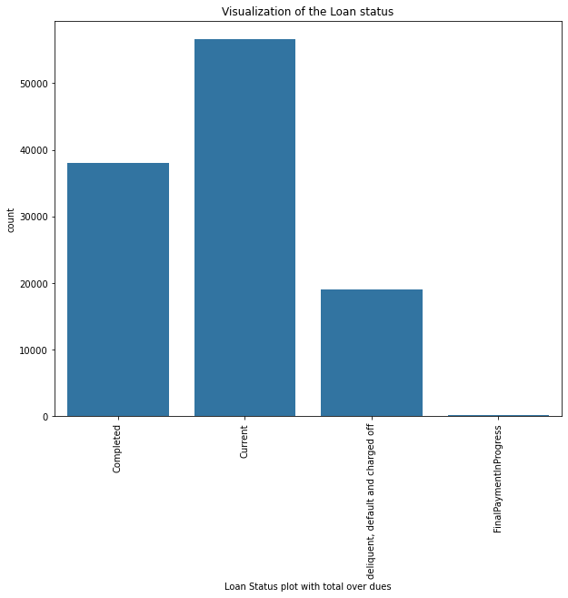

```python
#Plot of the Loanstatus summary
barchartplot(reduced_loan_clean, 'LoanStatusSummary')
plt.title('Visualization of the Loan status');
plt.xlabel('Loan Status plot with total over dues')
plt.xticks(rotation=90);
```

### Observations

> From the plot, we can observe that majority of the loan status is still currently on going, while a good amount is completed, some of the loan is has been charged off already. The over due loans is distributed among intervals of days. It will be good to see all the total over-dues.

> It is interesting to know that after combining the all the loans that are default, over due, charged off or cancelled, the loan status is still majorly completed or currently ongoing with no default yet.

Next, we look at the income range of the borrowers and see how it is distributed. We want to check according to this dataset, people of which income range are likely to seek for prosper loan.

### Question

> Which income range are likely to seek for prosper loan in this dataset?

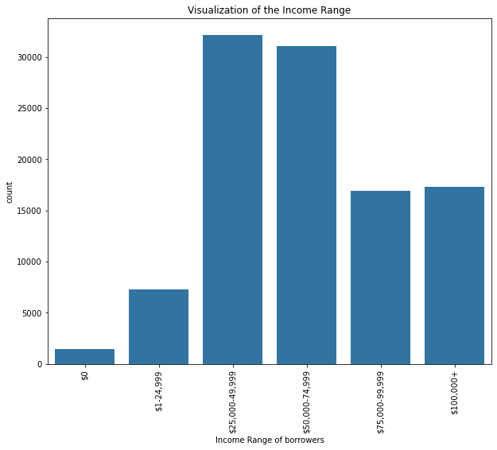

```python
#Univariable visualization of the Income range
barchartplot(reduced_loan_clean, 'IncomeRange')
plt.title('Visualization of the Income Range');
plt.xlabel('Income Range of borrowers')
plt.xticks(rotation=90);
```

### Observation

> we observe that people with income range of 25,000 to 75,000 are more popular in the prosper loan data set. We also observe that people with no zero income are very few which makes sense as it is quite difficult for people with no income to get be giving a loan.

Next we investigate the distribution of the borrower's Annual percentage range.

> In the prosper loan system, the Annual percentage range of a prosper borrower refer to the closing fee charged when you make your first borrow request. This fee is taken out of the loan amount you requested when the loan originates. Hence, the amount financed is always less than the borrower request amounts although the borrower pays back the full amount he requested.

> For example: A Prosper borrower with a B rating receives 2,425 in cash for a requested 2,500 loan. The difference of 75 is the closing fee that Prosper collects on the loan. However, the borrower is still responsible for paying back the full 2,500 over the term of the loan.

### Question

> What is the distribution of the Borrower's annual percentage rate?

### Visualization

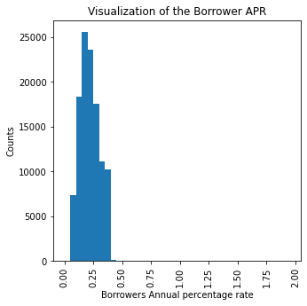

```python
#Histogram plot of the Borrower's APR
histchartplot(reduced_loan_clean, 'BorrowerAPR', bins)
plt.title('Visualization of the Borrower APR');
plt.xlabel('Borrowers Annual percentage rate')
plt.ylabel('Counts')
plt.xticks(rotation=90);
```

### Observation

The prosper score is also an interesting variable to visualise.

> The prosper score is a customer risk score built using historical data to assess the risk of a prosper borrower going default. The score ranges from 1 to 11 with 11 giving to a customer with the lowest risk while 1 is assign to customers with the highest risk of default.

### Question

> What is the distribution of the Prosper scores.

### Visualization

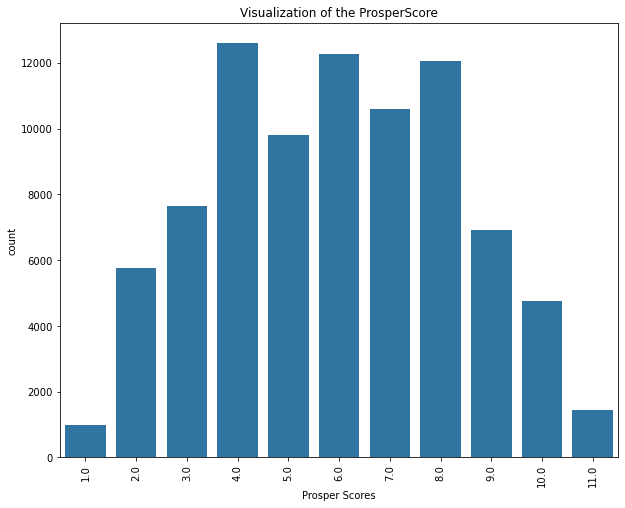

```python
# Bar plot of the prosperscore
barchartplot(reduced_loan_clean, 'ProsperScore')
plt.title('Visualization of the ProsperScore');
plt.xlabel('Prosper Scores')
plt.xticks(rotation=90);
```

### Observation

> We observe that there are few people with lowest risk of default as well as fewer with the highest risk. We can see that alot of borrowers has prosper score of 5, 6, 7, and 8. Although it is still disturbing to see alot of borrowers with a score of 4.

Next we visualise the Debt to income ratio of the borrowers

> Debt to income ratio of a borrower is an important financial health considered before a borrower is giving a loan. This simply define as the percentage of your gross monthly income (before taxes) that goes towards payments for rent, mortgage, credit cards, or other debt. To qualify for a Prosper personal loan, borrowers need a a debt-to-income (DTI) ratio that’s 50% as stated by [Investopedia](https://www.investopedia.com/prosper-personal-loans-review-4843741#:~:text=To%20qualify%20for%20a%20Prosper,score%20that's%20at%20least%20640.).

### Question

> What is the distribution of the Debt to income ratio of the borrowers?

### Visualization

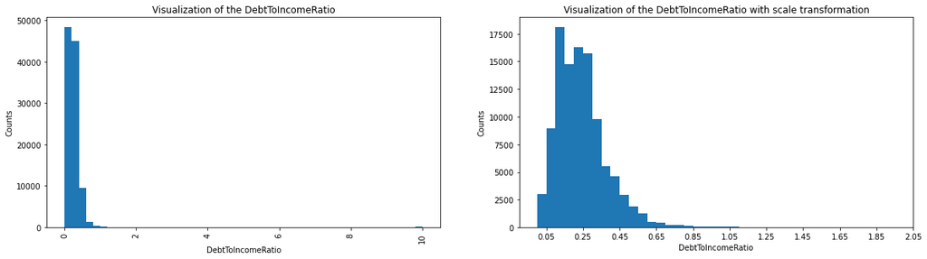

```python
#Histogram plot of the Borrower's DebtToIncomeRatio

plt.figure(figsize = [20, 5])
plt.subplot(1, 2, 1)
colors=sb.color_palette()[0]
plt.hist(data=reduced_loan_clean, x='DebtToIncomeRatio', color=colors, bins=50)
plt.title('Visualization of the DebtToIncomeRatio');
plt.xlabel('DebtToIncomeRatio')
plt.ylabel('Counts')
plt.xticks(rotation=90);

plt.subplot(1, 2, 2)
bins = np.arange(0, 1.5+0.5, 0.05)
colors=sb.color_palette()[0]
plt.hist(data=reduced_loan_clean, x='DebtToIncomeRatio', color=colors, bins=bins);
plt.title('Visualization of the DebtToIncomeRatio with scale transformation');
ticks = [0.05,0.25, 0.45, 0.65, 0.85, 1.05, 1.25, 1.45, 1.65, 1.85, 2.05]
labels = ['{}'.format(val) for val in ticks]
plt.xticks(ticks, labels);
plt.xlabel('DebtToIncomeRatio')
plt.ylabel('Counts');
```

### Observations

> The first plot of the debt to income ratio was not clear to understand. There seem to be very few people with debt to income ratio of 10 and so many empty space in between.

> The second figure on the right is a rescaled version of the debt to income ratio which zoom in on the most popular debt to income ratio value among the borrowers. The rescaled version showed a right-skewed distribution of debt to income ratio. We can observe that very few of the borrowers has debt to income ratio greater than the 50% while majority of the borrowers has a debt to income ratio less than 50%.

According to [Investopedia](https://www.investopedia.com/prosper-personal-loans-review-4843741#:~:text=To%20qualify%20for%20a%20Prosper,score%20that's%20at%20least%20640.), to qualify for a Prosper personal loan, borrowers need an annual income greater than $0, a debt-to-income (DTI) ratio that’s 50% or below, and a credit score that’s at least 640. We have seen the distribution of the debt-to-income (DTI), it will be interesting to look at the borrower's annual income and the credit score.

In the data set there we have the `CreditScoreRangeLower` and the `CreditScoreRangeUpper` which we can visualize side by side.

> The credit score helps to determines your creditworthiness, or how much of a risk it is for a lender to loan money to you. The higher the score the better it is for u to get a loan. According to [prosper.com](https://www.prosper.com/blog/decoding-your-credit-score-what-you-need-to-know/), Equifax ranking is as shown below:

Below 580: Poor credit

580–669: Fair credit

670–739: Good credit

740–799: Very good credit

800 and above: Excellent credit

> According to [prosper.com](https://www.prosper.com/blog/decoding-your-credit-score-what-you-need-to-know/), consumers in the 670 and up range generally have no trouble qualifying for credit commensurate with their income. People between 580–669 can still qualify for lines of credit, but will likely have to pay higher interest rates if they qualify for credit. However, those with scores below 580 may struggle to qualify for financing at all .

We will create a new column name average score since we have the and upper and lower range of credit score in the data.

```python
#Creating the Average Credit score
reduced_loan_clean['AverageCreditScore']=(reduced_loan_clean['CreditScoreRangeLower']+
reduced_loan_clean['CreditScoreRangeUpper'])/2
```

### Question

> What is the distribution of the credit scores?

### Visualization

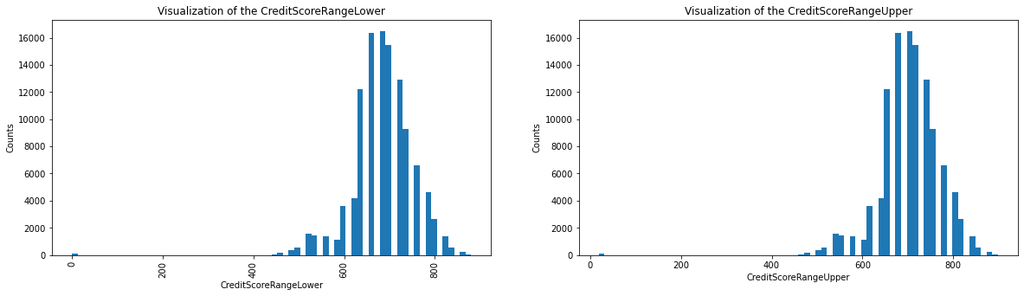

```python
#Histogram plot of the lower and upper credit score range.
plt.figure(figsize = [20, 5])

#Lower credit score plotting
plt.subplot(1, 2, 1)
colors=sb.color_palette()[0]
plt.hist(data=reduced_loan_clean, x='CreditScoreRangeLower', color=colors, bins=70);
plt.title('Visualization of the CreditScoreRangeLower');
plt.xlabel('CreditScoreRangeLower')
plt.ylabel('Counts')
plt.xticks(rotation=90);

#Upper credit credit score plotting
plt.subplot(1, 2, 2)
colors=sb.color_palette()[0]
plt.hist(data=reduced_loan_clean, x='CreditScoreRangeUpper', color=colors, bins=70);
plt.title('Visualization of the CreditScoreRangeUpper');
plt.xlabel('CreditScoreRangeUpper')
plt.ylabel('Counts');
```

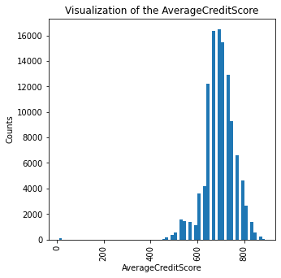

```python
#Histogram plot of the Average credit score
colors=sb.color_palette()[0]
plt.figure(figsize=(5,5))
plt.hist(data=reduced_loan_clean, x='AverageCreditScore', color=colors, bins=70);
plt.title('Visualization of the AverageCreditScore');
plt.xlabel('AverageCreditScore')
plt.ylabel('Counts')
plt.xticks(rotation=90);
```

### Observation

> We can observe that the distribution of the credit scores appears to be normally distributed from 420 and 900. The mean and median at the range of 685 and 680 respectively. Which is actually good as it appears that majority of the borrowers has a credit score greater than 600.

### Discuss the distribution(s) of your variable(s) of interest.

> `LoanStatus`: From the plot, we observed that majority of the loan status is still currently on going, while a good amount is completed, some of the loan is has been charged off already. The over due loans is distributed among intervals of days.

### Did you need to perform any transformations?

> `LoanStatus`: To get a better view of the distribution, I had to combine all the loans that are default, over due, charged off or cancelled and saving with a name `delinquent, default and charged off` .

### Of the features you investigated, were there any unusual distributions? Did you perform any operations on the data to tidy, adjust, or change the form of the data? If so, why did you do this?

> `ProsperScore`: The distribution shows the most popular prosper score being 4, 5, 6, 7 and 8.

> `DebtToIncomeRatio`: The distribution was right-skewed showing. Majority of the borrowers had a debt to income ratio less than 50%. I had to rescale the initial plot to get a clear view of the distribution.

> `Credit Score`: We can observe that the distribution of the credit scores appears to be normally distributed from 420 and 900. The mean and median at the range of 685 and 680 respectively. Which is actually good as it appears that majority of the borrowers has a credit score greater than 600. We took an average of the both the Lower and Upper credit score range. The distributions are all similar.

## Bivariate Exploration

> In this section, We will investigate the relationships between pairs of variables in the prosper loan data set.

First I will like to explore my first variable of interest which is the `BorrowerAPR` in relation to the credit score. I will be using the Average credit score which I have created in the previous section above.

### Questions

> Does a Credit score has effect on the Borrower's annual percentage rate?

### Visualization

```
-0.429707322058758
```

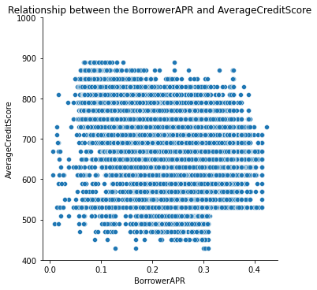

```python
#The borrowerAPR and the Credit score plotting
sb.relplot(x="BorrowerAPR", y="AverageCreditScore",data=reduced_loan_clean, kind="scatter");
plt.title('Relationship between the BorrowerAPR and AverageCreditScore');
plt.ylim(400, 1000)
print(reduced_loan_clean['BorrowerAPR'].corr(reduced_loan_clean['AverageCreditScore']))
```

### Observation

Next is to explore `BorrowerAPR` in relation with the Debt to income ratio.

### Questions

> Is there a correlation between `BorrowerAPR and the DebtToIncomeRatio`.

### Visualization

```
0.056327417443546045
```

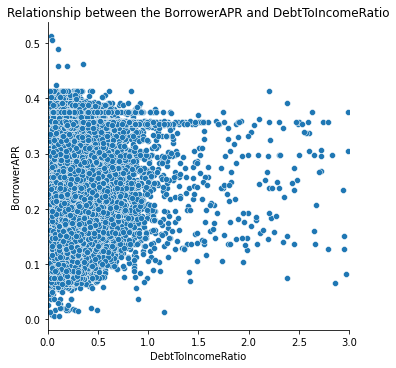

```python
#BorrowerAPR versus Debt to income ratio
sb.relplot(y="BorrowerAPR", x="DebtToIncomeRatio",data=reduced_loan_clean, kind="scatter");
plt.title('Relationship between the BorrowerAPR and DebtToIncomeRatio');
plt.xlim(0, 3)
print(reduced_loan_clean['BorrowerAPR'].corr(reduced_loan_clean['DebtToIncomeRatio']))
```

### Observation

> There appear to almost zero corelation between the BorrowerAPR and his debt to income ratio.

We next try to see if there is a relationship between the borrower annual percentage rate and the loan status using a box plot.

### Question

> Does borrowers who have successfully completed or are current with their loan have a lower annual percentage rate?

### Visualization

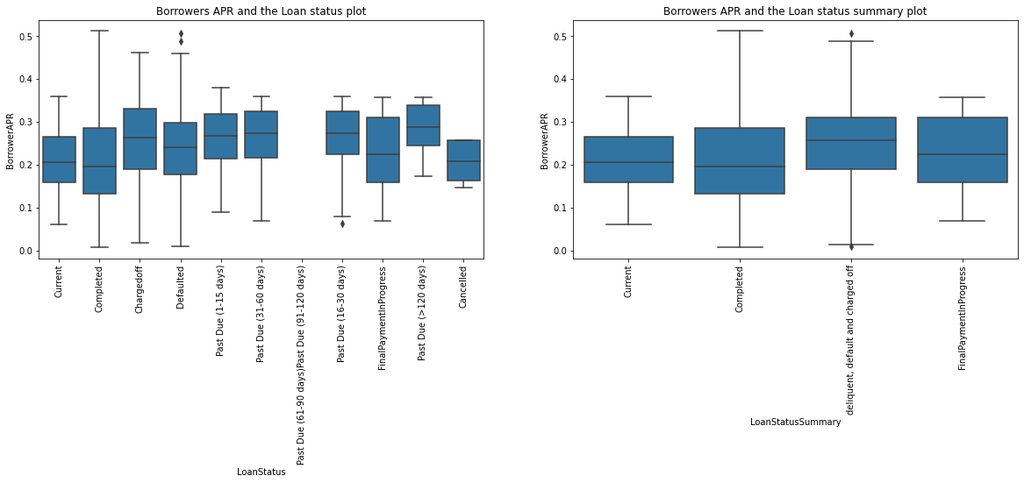

```python
#Converting the Loanstatus into cathegorical datatype
colors=sb.color_palette()[0]
plt.figure(figsize = [20, 5])

plt.subplot(1, 2, 1)

#Making a list of cathegories
loan_status = ['Current', 'Completed', 'Chargedoff', 'Defaulted',
                 'Past Due (1-15 days)', 'Past Due (31-60 days)', 'Past Due (61-90 days)'
                 'Past Due (91-120 days)', 'Past Due (16-30 days)', 'FinalPaymentInProgress',
                 'Past Due (>120 days)', 'Cancelled']


loanst = pd.api.types.CategoricalDtype(ordered=True, categories=loan_status)
reduced_loan_clean['LoanStatus'] = reduced_loan_clean['LoanStatus'].astype(loanst);
sb.boxplot(data=reduced_loan_clean, x='LoanStatus', y='BorrowerAPR', color=colors);
plt.title('Borrowers APR and the Loan status plot')
plt.xticks(rotation=90);

plt.subplot(1, 2, 2)
#List of summarized loan status cathegories
LoanStatus_Summary = ['Current', 'Completed', 'deliquent, default and charged off','FinalPaymentInProgress']

loanst_sum = pd.api.types.CategoricalDtype(ordered=True, categories=LoanStatus_Summary)
reduced_loan_clean['LoanStatusSummary'] = reduced_loan_clean['LoanStatusSummary'].astype(loanst_sum);
sb.boxplot(data=reduced_loan_clean, x='LoanStatusSummary', y='BorrowerAPR', color=colors);
plt.title('Borrowers APR and the Loan status summary plot')
plt.xticks(rotation=90);
```

### Observation

> From the image on the left, We can observe that 50% of borrowers who have completed their loan or current on their loan has lower value of annual percentage rate. For the current borrowers we can observe annual percentage rate of 21% awhile we can see about 19% for those who completed their loan. This is followed by those who are about to make their final payment, where the median value of the Borrowers APR is around 22%. We can also observe that cancelled loans also appear to have lower borrowerAPR.

### Question

We next investigate how much does the prosper loan score affect the a borrower's APR?

### Visualization

```python
#Since we aregoing to be having more of boxplot, lets define a function that plots boxplot

def boxchartplot(data, catvar, numvar):
    '''This function takes dataset and make a boxplot of two cathegorical variables
    from the dataset'''
    colors=sb.color_palette()[0]
    plt.figure(figsize=(10,5))
    sb.boxplot(data=data, x=catvar, y=numvar, color=colors);
```

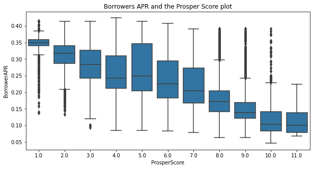

```python
#Plot of BorrowerAPR versus Prosperscore
boxchartplot(reduced_loan_clean, 'ProsperScore', 'BorrowerAPR')
plt.title('Borrowers APR and the Prosper Score plot');
```

### Observation

> The box plot above clearly depicts a strong effect of the prosper loan score on the borrower's APR. Prosper scores 1, 2, 3, 8, 9 and 10 shows alot of outliers. We can observe that people with better prosper score on an average tend to have lower annual percentage rate on their loan. This makes sense as prosper score is a risk assessment borrower, hence borrowers with lower risk are likely to to be given less percentage rate compared to those with higher risk of defaulting.

We have seen how the prosper score varies with the **BorrowerAPR**, lets see if the income range of a borrower can affect his annual percentage rate.

### Question

> Are people with higher income range giving lower annual percentage rate on thier loan?

### Visualization

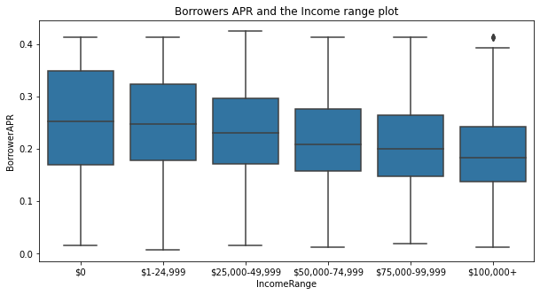

```python
#Plot of BorrowerAPR and IncomeRange
boxchartplot(reduced_loan_clean,'IncomeRange','BorrowerAPR')
plt.title('Borrowers APR and the Income range plot');
```

### Observation

> The plot shows a continues decrease in the annual percentage rate of borrowers as the income level increases. This shows that people with higher income are more likely to get a lower APR compared to those with lower income.

If that is the case, does that mean people with higher income have better chances of having a higher prosper score? This is something we can answer by showing the variation of the income level with the prosper score.

### Question

> How does the income level of a borrower affect the rate he is charged for the annual percentage?

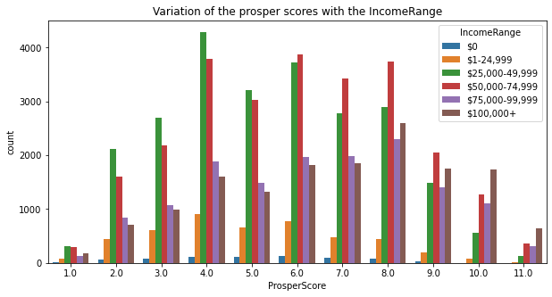

```python
#Plot of the prosperscore versus the income range
plt.figure(figsize=(10,5))
sb.countplot(data = reduced_loan_clean, x = 'ProsperScore', hue = 'IncomeRange');
plt.title('Variation of the prosper scores with the IncomeRange');
```

### Observation

> We can see from the plot that the income range definitely influences the prosper score of the borrower. We see that prosper score of 10 and 11 are more dominated with people with the highest range of income which is 100,000+. In our univariate plot we have seen that the borrowers are majorly people with income range of 25,000 to 49,000 and 50,000 to 74,000.

### Question

> How does the Credit score of a borrower affects the Prosper score?

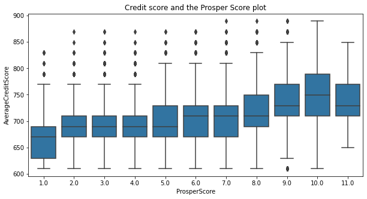

```python
#Plot of the prosperscore versus the credit score
boxchartplot(reduced_loan_clean,'ProsperScore', 'AverageCreditScore')
plt.title('Credit score and the Prosper Score plot');
```

### Observation

> The Credit score appears to affect the prosper score. The Prosper score of 1 majorly has the lowest credit score.. while prosper score of 10 seem to be of the highest average credit score.

If the borrower prosper scores has effect on the borrower's APR, does it also affect the Loan status? We would investigate this in the next plot below. For this plot, I will be making use of the Loanstatus summary only to have a clear view of the pattern.

### Question

> Does the prosper score has effect on the loan status?

### Visualization

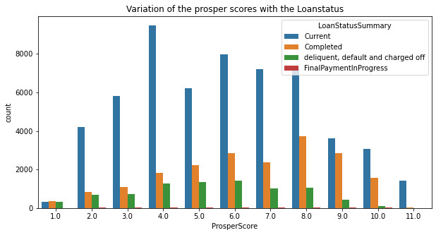

```python
#Visualization of the prosper score and the loanstatus summary
plt.figure(figsize=(10,5))
sb.countplot(data = reduced_loan_clean, x = 'ProsperScore', hue = 'LoanStatusSummary');
plt.title('Variation of the prosper scores with the Loanstatus')
```

### Observation

> This is interesting! Of cause we can observe that prosper score of 1 has low recored of loan status which is understandable as I presume it will be quite difficult to obtain a loan with a prosper record of 1. Now if we look at the distribution of the default loans across the prosper scores from 1 to 10, we observe that it appears to be normally distributed and it tends to start decreasing from 7 to 10. We also observe an increase in the number of completed loan progressively from 1 to 6 and then 8 being the highest. Currently active loan is high among the prosper score of 4 and 6. We can say indeed, people with high prosper score a likely not to default in their loan.

One more feature I wish to investigate the variation with the loan status is the Income range of the borrowers. My previous plot has shown that people of higher income seem to get more advantage in terms of BorrowerAPR and prosper score. The aim is to see if people of higher income range are more likely not to default in their loan servicing.

### Question

> Are people with higher income range more likely not to default in their loan status?

### Visualization

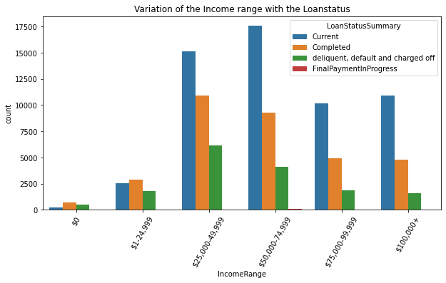

```python
plt.figure(figsize = [10, 5])
sb.countplot(data = reduced_loan_clean, x = 'IncomeRange', hue = 'LoanStatusSummary');
plt.title('Variation of the Income range with the Loanstatus')
plt.xticks(rotation=60);
```

### Observation

> The plot shows a very interesting outcome! lets pay attention to the **green** bar which represent **number of defaults**. We can observed that people with higher income range that is 75,000 to 100,000+ has least proportion of default if we compare to the other bars of loan status. we can see that the proportion of loan default decreases as the income range increases. No wonder people with high income range gets higher prosper score and lower BorrowerAPR.

### Talk about some of the relationships you observed in this part of the investigation. How did the feature(s) of interest vary with other features in the dataset?

#### BorrowerAPR and LoanStatus are our features of interest

We have plotted in this section to see the variation of the **Borrower's Annual Percentage rate** with the following features: **(a) Credit score (b) Debt to income ratio (c) Loan status (d) Prosper score (d) Income range**

> Our analysis shows are moderate negative correlation between a BorrowerAPR and his credit score. However, there seem to be a weak correlation with the BorrowerAPR and the debt to income ratio.

> We also observe good connection between the BorrowerAPR and the loanstatus. We saw that people who did not default in their loan servicing are more likely to have a lower BorrowerAPR.

> The prosper score showed a strong variation with the Borrower APR as well as the Loanstatus. We saw that people with higher prosper score appear to have lower borrowerAPR. The people with higher prosper score seem to be more likely not to default in their loan payment.

> The income range is another feature that appeared to influence the Borrower APR and the loan status. We saw that higher income range are associated with lower BorrowerAPR and less default loan payment.

### Did you observe any interesting relationships between the other features (not the main feature(s) of interest)?

> The income range and prosper score a two variables that shows are good connection with the Loanstatus and the BorrowerAPR. Plotting the two variables together shows a good connection between the two. We saw that prosper score of 10 and 11 are more dominated with people with the highest range of income which is 100,000+.

## Multivariate Exploration

> In this section, we create plots of three or more variables to investigate your data even further.

In this section, the goal is to take a deeper look at the variables and their relationships creating multivariate plots.

We will first look at the two variable of interest `BorrowerAPR` and `LoanStatus` and see how they varies for the various **Income range** in the data set. Recall that the income range has shown good connection between the BorrowerAPR and Loanstatus when plot individually with the income range.

### Question

> How does the Income range varies with the loan status and BorrowerAPR?

### Visualization

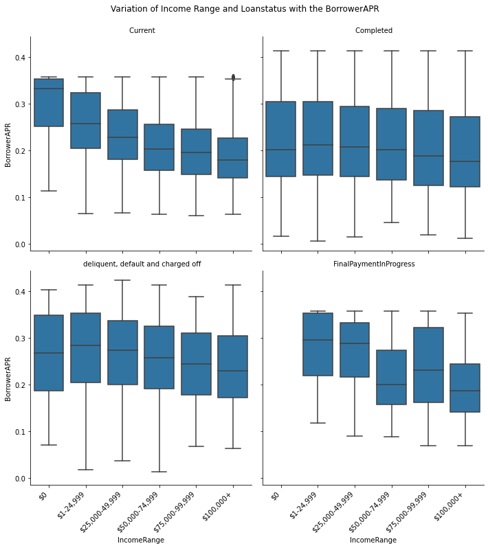

```python
colors=sb.color_palette()[0]
g = sb.catplot(x="IncomeRange",
                y="BorrowerAPR",
                data=reduced_loan_clean,
                kind="box",
                col="LoanStatusSummary", col_wrap=2, color=colors);
g.set_xticklabels(rotation=45, ha='right')
g.fig.suptitle("Variation of Income Range and Loanstatus with the BorrowerAPR",
               y=1.03);

g.set_titles(" {col_name}");
```

### Observation

> We observe that there is high variation in the annual percentage rate of borrowers who currently on loan. The APR decreases as the income range increase.

> However, for those who have completed their loan payment, we observe very little variation in the APR as the income level increase.

> We can observe that the defaulters shows a slight decrease trend (except in the cases of $0 income) in the APR as the income range increases.

We have seen how the Income range varies with the BorrowerAPR for each loan status. Now we investigate how other factors such as the prosper scores and credit score affect the BorrowerAPR.

### Question

> Does a high prosper score and credit score guarantee a low APR?

### Visualization

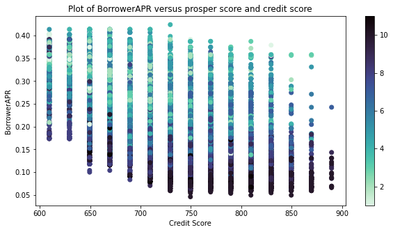

```python
#Visualizing the BorrowerAPR versus prosper score and credit score plot
plt.figure(figsize = [10, 5])
plt.scatter(data = reduced_loan_clean, x = 'AverageCreditScore', y = 'BorrowerAPR', c = 'ProsperScore',
            cmap = 'mako_r');
plt.colorbar()
plt.xlabel('Credit Score')
plt.ylabel('BorrowerAPR')
plt.title('Plot of BorrowerAPR versus prosper score and credit score');
```

### Observation

> We can observe from the plot that, having a high credit score may not necessarily guarantee a borrower low APR, having a high prosper score can help lower the APR. However, it is better to have both, a high credit score and prosper score. This can drastically reduce a borrower's APR.

Next we bring the income range again but this time with the prosper score.

### Question

> For each prosper score, how does the Income range affect the borrower's APR?

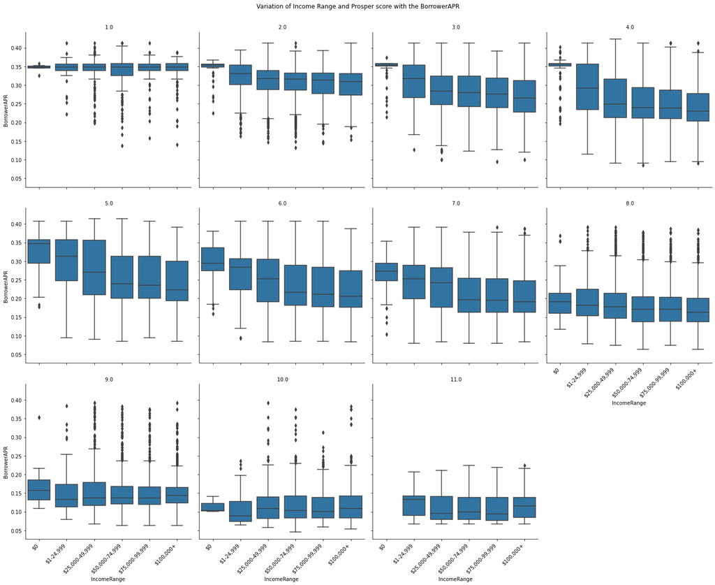

```python
colors=sb.color_palette()[0]
g = sb.catplot(x="IncomeRange",
                y="BorrowerAPR",
                data=reduced_loan_clean,
                kind="box",
                col="ProsperScore", col_wrap=4, color=colors);
g.set_xticklabels(rotation=45, ha='right')
g.fig.suptitle("Variation of Income Range and Prosper score with the BorrowerAPR",
               y=1.03);

g.set_titles(" {col_name}");
```

### Observation

> This plot gave a deeper look into to the importance of the Income range when compared to the prosper score in lowering the Borrower's APR.

> We can observe that first with prosper score of 1, the income range does not really affect the APR.

> But from prosper score of 2 to 7, the borrower APR reduce with increase in the Income range of the borrower.

> This trend seem to seize for borrower with prosper score of 9 to 11. Note that no one with income of 0 has a 11 prosper score and very few of this income group has a prosper score of 10.

Lets now look at the four variables which are the BorrowerAPR, ProsperScore, LoanStatus and the Income Range.

### Question

> For each income range how does the prosper score and the loan status affect the BorrowerAPR?

### Visualization

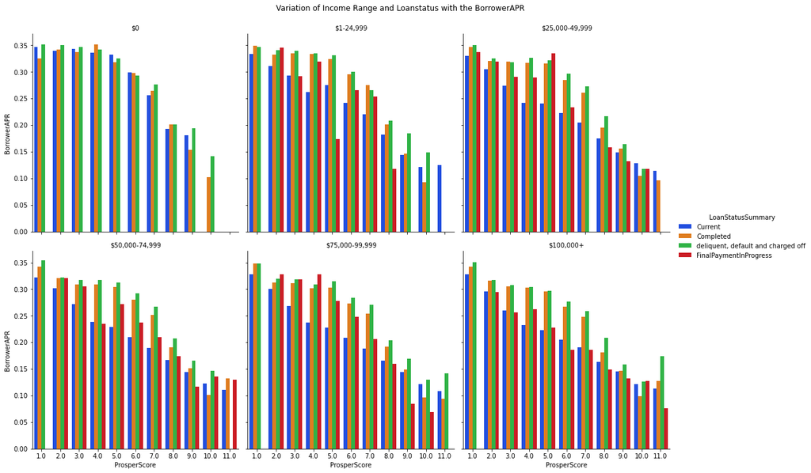

```python
g = sb.catplot(
        y='BorrowerAPR',x='ProsperScore',
        data=reduced_loan_clean,
        palette='bright',
        height=5,
        kind='bar',
        hue='LoanStatusSummary',
        col ='IncomeRange',
        col_wrap=3, ci=None)
g.set_titles(
    '{col_name}');


g.fig.suptitle("Variation of Income Range and Loanstatus with the BorrowerAPR",
               y=1.03);
```

### Observation

> First of we observe a general decreasing trend across all the income range as the prosper score increases, our focus now is on the Loanstatus.

> Studying the **green bar** which represent the defaulted loan, we observe that the borrower APR of the defaulters mostly over shoot other status at high prosper score rating across the income range.

> This shows that irrespective of the prosper score and income range, defaulters are likely to pay more APR than non-defaulters.

### Talk about some of the relationships you observed in this part of the investigation. Were there features that strengthened each other in terms of looking at your feature(s) of interest?

> In the multivariate plot, I try to investigate how 3 or more features affect the borrowerAPR.

> We observe that having a high credit score and prosper score boost a borrower's chances of having low APR.

### Were there any interesting or surprising interactions between features?

> We observe that The prosper score in any case has a strong influence on the borrower APR. Borrowers with high prosper score are usually favoured with lower APR.

## Conclusions

> The project goal was to investigate the features that affects the Borrower's annual percentage rate according to the data set. Additionally, the project also investigates the outcome of the loan and factors that are likely to affect the loan outcome. The supporting features selected are: `IncomeRange`, `Loanstatus`, `DebtToIncomeRatio`, `ProsperScore`, `CreditScoreRangeLower` and `CreditScoreRangeUpper`

> We observed that the **prosper score** has a great influence on the the borrowerAPR and even the outcome of the loan. The prosper score determine the risk of a customer defaulting in his loan. High prosper score means low risk and vice-versa.

> Borrowers who are seen to be of lower risk of defaulting in their loan are giving a lower annual percentage range. They have also show according to the dataset to have low probability of defaulting.

> We also observed that having a high prosper score and credit score will drastically reduce the borrower's APR.